# Travel Experiences

## Philippines

It was an overall enjoyable trip. The weather was awesome, the private water tours memorable and the Filipino food delicious.

**The best parts:**

- The excelent level of communications with Philippines EVANEOS vendor Junji.
- Working with Junji to have the best 22 day itinerary.
- Excelent transportation and coordination within Country.
- Good itinerary pace, with free time to explore areas on our own. Great selection of private tours.
- Most of the hotels were great.
- It was a great trip!

**The worst parts:**

- Not worst part, but it was annoying: WNOTE: Most of the hotels were great! Hovever, there were two hotels that did not meet expectations. To be fare, I am not sure if it was due to room availability or available hotel choices (****** (2nights -uneven floors and******(4 nights - shower overlapping with toilet area).

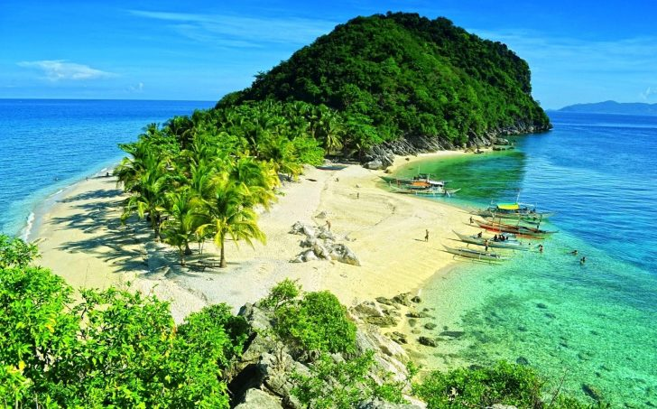

Philippines

## Japan

The first time I visited Japan was in the Spring this year and I loved it so much I booked straight away again through Evaneos and insisted on Yuri as my travel planner as before. On my first trip I flew back from Osaka and the night before I met a delightful couple from Hiroshima who urged me to visit…. So this time I did and was amazed to find a really lovely city and do welcoming….such lovely people….and later also in Nagasaki. Kyushu is beautiful with many fishing villages and harbours and I certainly intend to return.

**The best parts:**

- Everything….. Japan fascinates me at every turn

**The worst parts:**

- Packing to journey home!

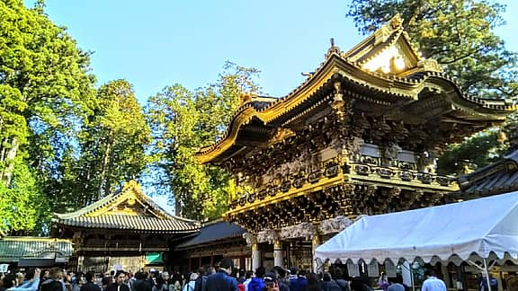

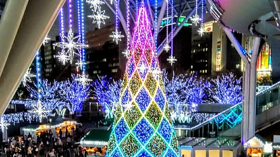

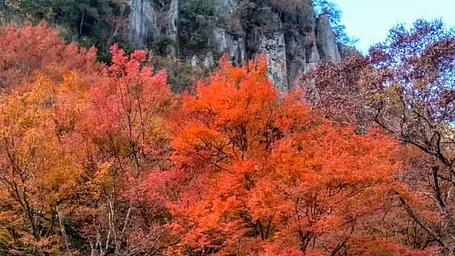

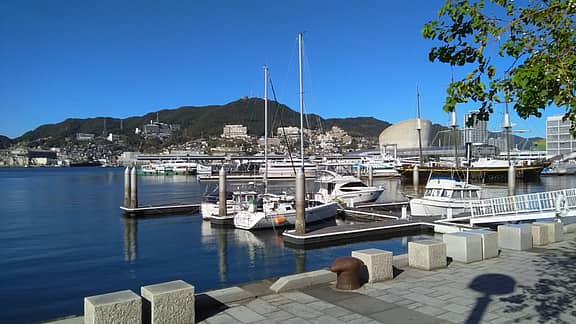